# Risk Factor Analysis

## Outcome Variable

**Outcome Variable:** swasted

## Predictor Variables

**Intervention Variable:** earlybf

**Adjustment Set:**

- arm
- sex
- W_mage
- meducyrs
- feducyrs
- hhwealth_quart
- hfoodsec
- W_mhtcm
- W_mwtkg
- W_mbmi
- vagbrth
- W_gagebrth
- W_birthwt
- W_birthlen
- W_nrooms
- W_nchldlt5
- brthmon
- W_parity
- impfloor
- impsan
- safeh20
- delta_W_mage
- delta_meducyrs
- delta_feducyrs
- delta_hhwealth_quart
- delta_hfoodsec
- delta_W_mhtcm
- delta_W_mwtkg
- delta_W_mbmi
- delta_vagbrth
- delta_W_gagebrth
- delta_W_birthwt
- delta_W_birthlen
- delta_W_nrooms
- delta_W_nchldlt5
- delta_brthmon
- delta_W_parity
- delta_impfloor
- delta_impsan
- delta_safeh20

## Stratifying Variables

The analysis was stratified on these variable(s):

- agecat
- studyid
- country

## Data Summary

| agecat | studyid | country | earlybf | swasted | n_cell | n |
| --- | --- | --- | --- | --- | --- | --- |
| Birth | ki0047075b-MAL-ED | BANGLADESH | 1 | 0 | 135 | 214 |
| Birth | ki0047075b-MAL-ED | BANGLADESH | 1 | 1 | 5 | 214 |
| Birth | ki0047075b-MAL-ED | BANGLADESH | 0 | 0 | 71 | 214 |
| Birth | ki0047075b-MAL-ED | BANGLADESH | 0 | 1 | 3 | 214 |
| Birth | ki0047075b-MAL-ED | BRAZIL | 1 | 0 | 26 | 62 |
| Birth | ki0047075b-MAL-ED | BRAZIL | 1 | 1 | 0 | 62 |
| Birth | ki0047075b-MAL-ED | BRAZIL | 0 | 0 | 36 | 62 |
| Birth | ki0047075b-MAL-ED | BRAZIL | 0 | 1 | 0 | 62 |
| Birth | ki0047075b-MAL-ED | INDIA | 1 | 0 | 31 | 44 |
| Birth | ki0047075b-MAL-ED | INDIA | 1 | 1 | 0 | 44 |
| Birth | ki0047075b-MAL-ED | INDIA | 0 | 0 | 13 | 44 |
| Birth | ki0047075b-MAL-ED | INDIA | 0 | 1 | 0 | 44 |
| Birth | ki0047075b-MAL-ED | NEPAL | 1 | 0 | 14 | 26 |
| Birth | ki0047075b-MAL-ED | NEPAL | 1 | 1 | 0 | 26 |
| Birth | ki0047075b-MAL-ED | NEPAL | 0 | 0 | 11 | 26 |
| Birth | ki0047075b-MAL-ED | NEPAL | 0 | 1 | 1 | 26 |
| Birth | ki0047075b-MAL-ED | PERU | 1 | 0 | 172 | 228 |
| Birth | ki0047075b-MAL-ED | PERU | 1 | 1 | 0 | 228 |
| Birth | ki0047075b-MAL-ED | PERU | 0 | 0 | 56 | 228 |
| Birth | ki0047075b-MAL-ED | PERU | 0 | 1 | 0 | 228 |
| Birth | ki0047075b-MAL-ED | SOUTH AFRICA | 1 | 0 | 69 | 110 |
| Birth | ki0047075b-MAL-ED | SOUTH AFRICA | 1 | 1 | 0 | 110 |
| Birth | ki0047075b-MAL-ED | SOUTH AFRICA | 0 | 0 | 41 | 110 |
| Birth | ki0047075b-MAL-ED | SOUTH AFRICA | 0 | 1 | 0 | 110 |
| Birth | ki0047075b-MAL-ED | TANZANIA, UNITED REPUBLIC OF | 1 | 0 | 103 | 115 |
| Birth | ki0047075b-MAL-ED | TANZANIA, UNITED REPUBLIC OF | 1 | 1 | 0 | 115 |
| Birth | ki0047075b-MAL-ED | TANZANIA, UNITED REPUBLIC OF | 0 | 0 | 12 | 115 |
| Birth | ki0047075b-MAL-ED | TANZANIA, UNITED REPUBLIC OF | 0 | 1 | 0 | 115 |
| Birth | ki1000109-EE | PAKISTAN | 1 | 0 | 34 | 170 |
| Birth | ki1000109-EE | PAKISTAN | 1 | 1 | 2 | 170 |

[output cut: 134 more lines]

The following strata were considered:

- agecat: 24 months, studyid: ki0047075b-MAL-ED, country: BANGLADESH
- agecat: 24 months, studyid: ki0047075b-MAL-ED, country: BRAZIL
- agecat: 24 months, studyid: ki0047075b-MAL-ED, country: INDIA
- agecat: 24 months, studyid: ki0047075b-MAL-ED, country: NEPAL
- agecat: 24 months, studyid: ki0047075b-MAL-ED, country: PERU
- agecat: 24 months, studyid: ki0047075b-MAL-ED, country: SOUTH AFRICA
- agecat: 24 months, studyid: ki0047075b-MAL-ED, country: TANZANIA, UNITED REPUBLIC OF
- agecat: 24 months, studyid: ki1000109-EE, country: PAKISTAN
- agecat: 24 months, studyid: ki1017093c-NIH-Crypto, country: BANGLADESH
- agecat: 24 months, studyid: ki1113344-GMS-Nepal, country: NEPAL
- agecat: 24 months, studyid: ki1126311-ZVITAMBO, country: ZIMBABWE
- agecat: 24 months, studyid: kiGH5241-JiVitA-3, country: BANGLADESH
- agecat: 24 months, studyid: kiGH5241-JiVitA-4, country: BANGLADESH
- agecat: 6 months, studyid: ki0047075b-MAL-ED, country: BANGLADESH
- agecat: 6 months, studyid: ki0047075b-MAL-ED, country: BRAZIL
- agecat: 6 months, studyid: ki0047075b-MAL-ED, country: INDIA
- agecat: 6 months, studyid: ki0047075b-MAL-ED, country: NEPAL
- agecat: 6 months, studyid: ki0047075b-MAL-ED, country: PERU
- agecat: 6 months, studyid: ki0047075b-MAL-ED, country: SOUTH AFRICA
- agecat: 6 months, studyid: ki0047075b-MAL-ED, country: TANZANIA, UNITED REPUBLIC OF
- agecat: 6 months, studyid: ki1000109-EE, country: PAKISTAN
- agecat: 6 months, studyid: ki1000304b-SAS-CompFeed, country: INDIA
- agecat: 6 months, studyid: ki1017093c-NIH-Crypto, country: BANGLADESH
- agecat: 6 months, studyid: ki1113344-GMS-Nepal, country: NEPAL
- agecat: 6 months, studyid: ki1126311-ZVITAMBO, country: ZIMBABWE
- agecat: 6 months, studyid: kiGH5241-JiVitA-3, country: BANGLADESH
- agecat: 6 months, studyid: kiGH5241-JiVitA-4, country: BANGLADESH
- agecat: Birth, studyid: ki0047075b-MAL-ED, country: BANGLADESH
- agecat: Birth, studyid: ki0047075b-MAL-ED, country: BRAZIL
- agecat: Birth, studyid: ki0047075b-MAL-ED, country: INDIA
- agecat: Birth, studyid: ki0047075b-MAL-ED, country: NEPAL
- agecat: Birth, studyid: ki0047075b-MAL-ED, country: PERU
- agecat: Birth, studyid: ki0047075b-MAL-ED, country: SOUTH AFRICA
- agecat: Birth, studyid: ki0047075b-MAL-ED, country: TANZANIA, UNITED REPUBLIC OF
- agecat: Birth, studyid: ki1000109-EE, country: PAKISTAN
- agecat: Birth, studyid: ki1000304b-SAS-CompFeed, country: INDIA
- agecat: Birth, studyid: ki1017093c-NIH-Crypto, country: BANGLADESH
- agecat: Birth, studyid: ki1113344-GMS-Nepal, country: NEPAL
- agecat: Birth, studyid: ki1126311-ZVITAMBO, country: ZIMBABWE
- agecat: Birth, studyid: kiGH5241-JiVitA-3, country: BANGLADESH
- agecat: Birth, studyid: kiGH5241-JiVitA-4, country: BANGLADESH

### Dropped Strata

Some strata were dropped due to rare outcomes:

- agecat: Birth, studyid: ki0047075b-MAL-ED, country: BANGLADESH
- agecat: Birth, studyid: ki0047075b-MAL-ED, country: BRAZIL
- agecat: Birth, studyid: ki0047075b-MAL-ED, country: INDIA
- agecat: Birth, studyid: ki0047075b-MAL-ED, country: NEPAL
- agecat: Birth, studyid: ki0047075b-MAL-ED, country: PERU
- agecat: Birth, studyid: ki0047075b-MAL-ED, country: SOUTH AFRICA
- agecat: Birth, studyid: ki0047075b-MAL-ED, country: TANZANIA, UNITED REPUBLIC OF
- agecat: Birth, studyid: ki1000109-EE, country: PAKISTAN
- agecat: Birth, studyid: ki1000304b-SAS-CompFeed, country: INDIA
- agecat: Birth, studyid: kiGH5241-JiVitA-3, country: BANGLADESH
- agecat: 6 months, studyid: ki0047075b-MAL-ED, country: BANGLADESH
- agecat: 6 months, studyid: ki0047075b-MAL-ED, country: BRAZIL
- agecat: 6 months, studyid: ki0047075b-MAL-ED, country: INDIA
- agecat: 6 months, studyid: ki0047075b-MAL-ED, country: NEPAL
- agecat: 6 months, studyid: ki0047075b-MAL-ED, country: PERU
- agecat: 6 months, studyid: ki0047075b-MAL-ED, country: SOUTH AFRICA
- agecat: 6 months, studyid: ki0047075b-MAL-ED, country: TANZANIA, UNITED REPUBLIC OF
- agecat: 6 months, studyid: ki1000109-EE, country: PAKISTAN
- agecat: 6 months, studyid: ki1017093c-NIH-Crypto, country: BANGLADESH
- agecat: 6 months, studyid: ki1113344-GMS-Nepal, country: NEPAL
- agecat: 6 months, studyid: kiGH5241-JiVitA-3, country: BANGLADESH
- agecat: 24 months, studyid: ki0047075b-MAL-ED, country: BANGLADESH
- agecat: 24 months, studyid: ki0047075b-MAL-ED, country: BRAZIL
- agecat: 24 months, studyid: ki0047075b-MAL-ED, country: INDIA
- agecat: 24 months, studyid: ki0047075b-MAL-ED, country: NEPAL
- agecat: 24 months, studyid: ki0047075b-MAL-ED, country: PERU
- agecat: 24 months, studyid: ki0047075b-MAL-ED, country: SOUTH AFRICA
- agecat: 24 months, studyid: ki0047075b-MAL-ED, country: TANZANIA, UNITED REPUBLIC OF
- agecat: 24 months, studyid: ki1000109-EE, country: PAKISTAN
- agecat: 24 months, studyid: ki1017093c-NIH-Crypto, country: BANGLADESH
- agecat: 24 months, studyid: ki1113344-GMS-Nepal, country: NEPAL
- agecat: 24 months, studyid: kiGH5241-JiVitA-3, country: BANGLADESH

## Methods Detail

We’re interested in the causal parameters $E[Y_a]$ for all values of $a \in \mathcal{A}$. These parameters represent the mean outcome if, possibly contrary to fact, we intervened to set all units to have $A=a$. Under the randomization and positivity assumptions, these are identified by the statistical parameters $\psi_a=E_W[E_{Y|A,W}(Y|A=a,W)]$. In addition, we’re interested in the mean of $Y$, $E[Y]$ under no intervention (the observed mean). We will estimate these parameters by using SuperLearner to fit the relevant likelihood factors – $E_{Y|A,W}(Y|A=a,W)$ and $p(A=a|W)$, and then updating our likelihood fit using a joint TMLE.

For unadjusted analyses ($W=\{\}$), initial likelihoods were estimated using Lrnr_glm to estimate the simple $E(Y|A)$ and Lrnr_mean to estimate $p(A)$. For adjusted analyses, a small library containing Lrnr_glmnet, Lrnr_xgboost, and Lrnr_mean was used.

Having estimated these parameters, we will then use the delta method to estimate relative risks and attributable risks relative to a prespecified baseline level of $A$.

# Results Detail

## Results Plots

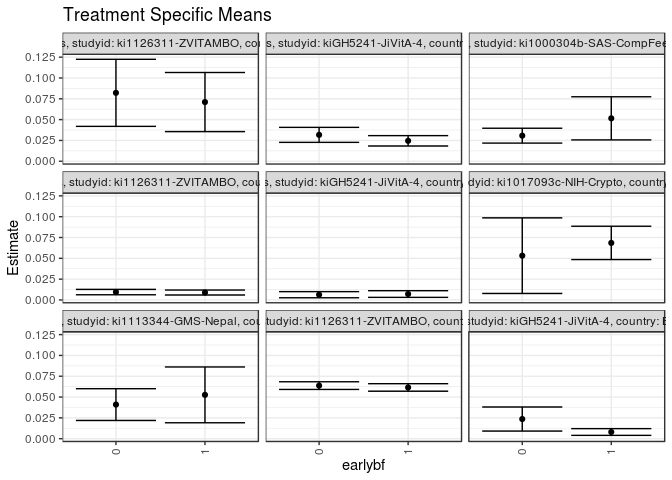

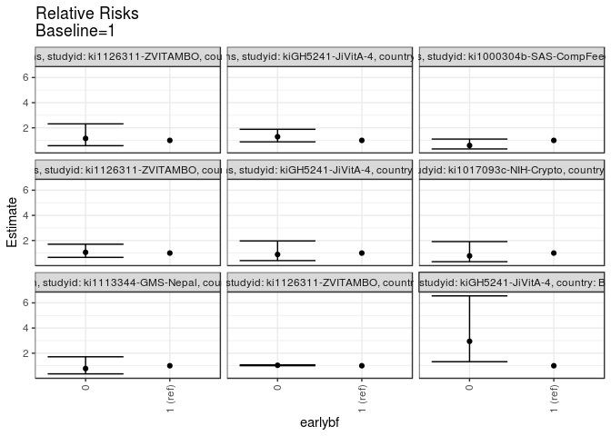

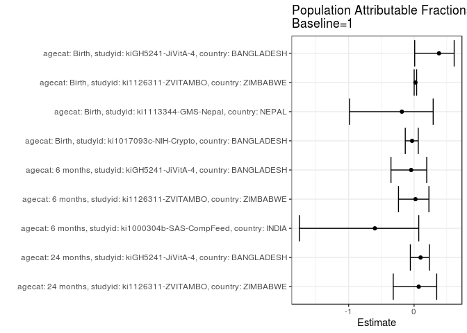

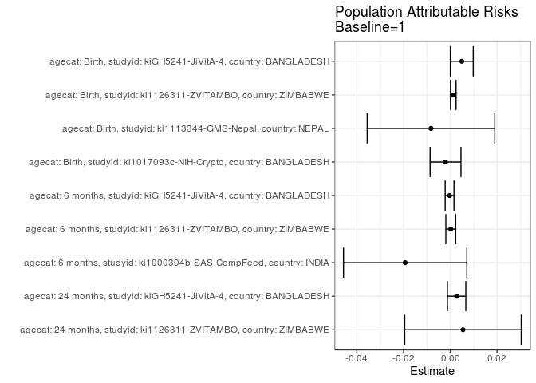

## Results Table

### Parameter: TSM

| agecat | studyid | country | intervention_level | baseline_level | estimate | ci_lower | ci_upper |
| --- | --- | --- | --- | --- | --- | --- | --- |
| Birth | ki1017093c-NIH-Crypto | BANGLADESH | 1 | NA | 0.0685155 | 0.0485027 | 0.0885283 |
| Birth | ki1017093c-NIH-Crypto | BANGLADESH | 0 | NA | 0.0531915 | 0.0077928 | 0.0985902 |
| Birth | ki1113344-GMS-Nepal | NEPAL | 1 | NA | 0.0526316 | 0.0191348 | 0.0861284 |
| Birth | ki1113344-GMS-Nepal | NEPAL | 0 | NA | 0.0409639 | 0.0218779 | 0.0600498 |
| Birth | ki1126311-ZVITAMBO | ZIMBABWE | 1 | NA | 0.0615209 | 0.0570146 | 0.0660272 |
| Birth | ki1126311-ZVITAMBO | ZIMBABWE | 0 | NA | 0.0637644 | 0.0591577 | 0.0683712 |
| Birth | kiGH5241-JiVitA-4 | BANGLADESH | 1 | NA | 0.0080133 | 0.0039730 | 0.0120536 |
| Birth | kiGH5241-JiVitA-4 | BANGLADESH | 0 | NA | 0.0236005 | 0.0091403 | 0.0380607 |
| 6 months | ki1000304b-SAS-CompFeed | INDIA | 1 | NA | 0.0515464 | 0.0256358 | 0.0774570 |
| 6 months | ki1000304b-SAS-CompFeed | INDIA | 0 | NA | 0.0307195 | 0.0217846 | 0.0396544 |
| 6 months | ki1126311-ZVITAMBO | ZIMBABWE | 1 | NA | 0.0089383 | 0.0059655 | 0.0119111 |
| 6 months | ki1126311-ZVITAMBO | ZIMBABWE | 0 | NA | 0.0094658 | 0.0062487 | 0.0126829 |
| 6 months | kiGH5241-JiVitA-4 | BANGLADESH | 1 | NA | 0.0071331 | 0.0031433 | 0.0111228 |
| 6 months | kiGH5241-JiVitA-4 | BANGLADESH | 0 | NA | 0.0063376 | 0.0026528 | 0.0100225 |
| 24 months | ki1126311-ZVITAMBO | ZIMBABWE | 1 | NA | 0.0710800 | 0.0356123 | 0.1065478 |
| 24 months | ki1126311-ZVITAMBO | ZIMBABWE | 0 | NA | 0.0821658 | 0.0418945 | 0.1224370 |
| 24 months | kiGH5241-JiVitA-4 | BANGLADESH | 1 | NA | 0.0245386 | 0.0183027 | 0.0307746 |
| 24 months | kiGH5241-JiVitA-4 | BANGLADESH | 0 | NA | 0.0316932 | 0.0226790 | 0.0407075 |

### Parameter: E(Y)

| agecat | studyid | country | intervention_level | baseline_level | estimate | ci_lower | ci_upper |
| --- | --- | --- | --- | --- | --- | --- | --- |
| Birth | ki1017093c-NIH-Crypto | BANGLADESH | NA | NA | 0.0664781 | 0.0481022 | 0.0848539 |
| Birth | ki1113344-GMS-Nepal | NEPAL | NA | NA | 0.0443686 | 0.0276826 | 0.0610546 |
| Birth | ki1126311-ZVITAMBO | ZIMBABWE | NA | NA | 0.0627931 | 0.0583619 | 0.0672244 |
| Birth | kiGH5241-JiVitA-4 | BANGLADESH | NA | NA | 0.0129382 | 0.0075150 | 0.0183614 |
| 6 months | ki1000304b-SAS-CompFeed | INDIA | NA | NA | 0.0322339 | 0.0235219 | 0.0409459 |
| 6 months | ki1126311-ZVITAMBO | ZIMBABWE | NA | NA | 0.0091354 | 0.0069896 | 0.0112812 |
| 6 months | kiGH5241-JiVitA-4 | BANGLADESH | NA | NA | 0.0068281 | 0.0038634 | 0.0097927 |
| 24 months | ki1126311-ZVITAMBO | ZIMBABWE | NA | NA | 0.0765172 | 0.0497195 | 0.1033148 |
| 24 months | kiGH5241-JiVitA-4 | BANGLADESH | NA | NA | 0.0272439 | 0.0220352 | 0.0324527 |

### Parameter: RR

| agecat | studyid | country | intervention_level | baseline_level | estimate | ci_lower | ci_upper |
| --- | --- | --- | --- | --- | --- | --- | --- |
| Birth | ki1017093c-NIH-Crypto | BANGLADESH | 1 | 1 | 1.0000000 | 1.0000000 | 1.000000 |
| Birth | ki1017093c-NIH-Crypto | BANGLADESH | 0 | 1 | 0.7763425 | 0.3149772 | 1.913496 |
| Birth | ki1113344-GMS-Nepal | NEPAL | 1 | 1 | 1.0000000 | 1.0000000 | 1.000000 |
| Birth | ki1113344-GMS-Nepal | NEPAL | 0 | 1 | 0.7783133 | 0.3536728 | 1.712802 |
| Birth | ki1126311-ZVITAMBO | ZIMBABWE | 1 | 1 | 1.0000000 | 1.0000000 | 1.000000 |
| Birth | ki1126311-ZVITAMBO | ZIMBABWE | 0 | 1 | 1.0364682 | 1.0011657 | 1.073015 |
| Birth | kiGH5241-JiVitA-4 | BANGLADESH | 1 | 1 | 1.0000000 | 1.0000000 | 1.000000 |
| Birth | kiGH5241-JiVitA-4 | BANGLADESH | 0 | 1 | 2.9451701 | 1.3226722 | 6.557957 |
| 6 months | ki1000304b-SAS-CompFeed | INDIA | 1 | 1 | 1.0000000 | 1.0000000 | 1.000000 |
| 6 months | ki1000304b-SAS-CompFeed | INDIA | 0 | 1 | 0.5959580 | 0.3210516 | 1.106258 |
| 6 months | ki1126311-ZVITAMBO | ZIMBABWE | 1 | 1 | 1.0000000 | 1.0000000 | 1.000000 |
| 6 months | ki1126311-ZVITAMBO | ZIMBABWE | 0 | 1 | 1.0590112 | 0.6582685 | 1.703719 |
| 6 months | kiGH5241-JiVitA-4 | BANGLADESH | 1 | 1 | 1.0000000 | 1.0000000 | 1.000000 |
| 6 months | kiGH5241-JiVitA-4 | BANGLADESH | 0 | 1 | 0.8884872 | 0.4012888 | 1.967185 |
| 24 months | ki1126311-ZVITAMBO | ZIMBABWE | 1 | 1 | 1.0000000 | 1.0000000 | 1.000000 |
| 24 months | ki1126311-ZVITAMBO | ZIMBABWE | 0 | 1 | 1.1559615 | 0.5773714 | 2.314363 |
| 24 months | kiGH5241-JiVitA-4 | BANGLADESH | 1 | 1 | 1.0000000 | 1.0000000 | 1.000000 |
| 24 months | kiGH5241-JiVitA-4 | BANGLADESH | 0 | 1 | 1.2915643 | 0.8853630 | 1.884129 |

### Parameter: PAR

| agecat | studyid | country | intervention_level | baseline_level | estimate | ci_lower | ci_upper |
| --- | --- | --- | --- | --- | --- | --- | --- |
| Birth | ki1017093c-NIH-Crypto | BANGLADESH | 1 | NA | -0.0020374 | -0.0086451 | 0.0045702 |
| Birth | ki1113344-GMS-Nepal | NEPAL | 1 | NA | -0.0082630 | -0.0355690 | 0.0190431 |
| Birth | ki1126311-ZVITAMBO | ZIMBABWE | 1 | NA | 0.0012722 | 0.0000844 | 0.0024601 |
| Birth | kiGH5241-JiVitA-4 | BANGLADESH | 1 | NA | 0.0049249 | 0.0000233 | 0.0098266 |
| 6 months | ki1000304b-SAS-CompFeed | INDIA | 1 | NA | -0.0193125 | -0.0457136 | 0.0070885 |
| 6 months | ki1126311-ZVITAMBO | ZIMBABWE | 1 | NA | 0.0001971 | -0.0019079 | 0.0023021 |
| 6 months | kiGH5241-JiVitA-4 | BANGLADESH | 1 | NA | -0.0003050 | -0.0021885 | 0.0015785 |
| 24 months | ki1126311-ZVITAMBO | ZIMBABWE | 1 | NA | 0.0054371 | -0.0195064 | 0.0303807 |
| 24 months | kiGH5241-JiVitA-4 | BANGLADESH | 1 | NA | 0.0027053 | -0.0012325 | 0.0066430 |

### Parameter: PAF

| agecat | studyid | country | intervention_level | baseline_level | estimate | ci_lower | ci_upper |
| --- | --- | --- | --- | --- | --- | --- | --- |
| Birth | ki1017093c-NIH-Crypto | BANGLADESH | 1 | NA | -0.0306480 | -0.1346550 | 0.0638253 |
| Birth | ki1113344-GMS-Nepal | NEPAL | 1 | NA | -0.1862348 | -0.9869502 | 0.2918026 |
| Birth | ki1126311-ZVITAMBO | ZIMBABWE | 1 | NA | 0.0202608 | 0.0012070 | 0.0389512 |
| Birth | kiGH5241-JiVitA-4 | BANGLADESH | 1 | NA | 0.3806503 | 0.0094427 | 0.6127492 |
| 6 months | ki1000304b-SAS-CompFeed | INDIA | 1 | NA | -0.5991369 | -1.7539793 | 0.0714386 |
| 6 months | ki1126311-ZVITAMBO | ZIMBABWE | 1 | NA | 0.0215790 | -0.2381650 | 0.2268335 |
| 6 months | kiGH5241-JiVitA-4 | BANGLADESH | 1 | NA | -0.0446704 | -0.3530983 | 0.1934539 |
| 24 months | ki1126311-ZVITAMBO | ZIMBABWE | 1 | NA | 0.0710576 | -0.3186202 | 0.3455780 |
| 24 months | kiGH5241-JiVitA-4 | BANGLADESH | 1 | NA | 0.0992985 | -0.0569064 | 0.2324172 |